# La traviata

Melodramma in drei Akten (1853)

Musik von

Giuseppe Verdi

Text von

Francesco Maria Piave nach Alexandre Dumas d. J.

»Die vom rechten Wege Abgekommene« – das ist Violetta Valéry, die als Edelkurtisane in Paris ein Leben zwischen Glanz und Elend führt. Alles ist nur Spiel und Schein, auch die Liebe, bis Alfredo Germont in ihr wahre Gefühle erweckt. Das Glück aber ist ein seltener Gast und nur von kurzer Dauer: Violetta, an Schwindsucht leidet, wird erst gedemütigt und vergeht nach einem letzten Aufflackern ihrer Lebenskräfte.

Ein einziges Mal nur hat sich Giuseppe Verdi einem zeitgenössischen Sujet zugewandt, der »Kameliendame« des Pariser Autors Alexandre Dumas d.J. Als Roman wie als Theaterstück hat Dumas dieses auf wahren Begebenheiten beruhende Geschehen literarisch gestaltet. Verdi erfand dazu eine Musik von großer Eindringlichkeit, die dem Ausdruck von Emotionen viel Raum lässt: Freude und Überschwang, Klage und Verzweiflung. Der Hörer und Betrachter wird sogartig in die Handlung hineingenommen, um ganz unmittelbar am Schicksal Violettas Anteil zu nehmen. Als letztes Werk der sogenannten »Trilogia populare« ist die 1853 uraufgeführte und 1860 erstmals im Haus Unter den Linden gezeigte »Traviata« nach anfänglicher Skepsis rasch zu einer Erfolgsoper im internationalen Maßstab geworden. Die Inszenierung von Dieter Dorn lässt Violetta als eine Frau erscheinen, die von Anfang an eine Todgeweihte ist, sich aber gegen ihr Schicksal auflehnt. Am Ende ist sie einfach verschwunden, wie ins Nichts aufgelöst.

## Termine

Do. 21. April 2022 19.30 Uhr

[Staatsoper Unter den Linden](https://www.staatsoper-berlin.de/de/ihr-besuch/anfahrt/staatsoper-unter-den-linden.35/)

Dauer: ca. 2:40 h inklusive einer Pause nach dem 1. Bild des 2. Akts

Sprache: In italienischer Sprache mit deutschen und englischen Übertiteln

Altersempfehlung: ab 12 Jahren

## Besetzung

- Musikalische Leitung
  - [Massimo Zanetti](https://www.staatsoper-berlin.de/de/kuenstler/massimo-zanetti.1096/)
- Inszenierung
  - [Dieter Dorn](https://www.staatsoper-berlin.de/de/kuenstler/dieter-dorn.1041/)
- Bühnenbild
  - [Joanna Piestrzyńska](https://www.staatsoper-berlin.de/de/kuenstler/joanna-piestrzynska.1043/)
- Kostüme
  - [Moidele Bickel](https://www.staatsoper-berlin.de/de/kuenstler/moidele-bickel.1044/)
- Licht
  - [Tobias Löffler](https://www.staatsoper-berlin.de/de/kuenstler/tobias-loeffler.1045/)
- Choreographie
  - [Martin Gruber](https://www.staatsoper-berlin.de/de/kuenstler/martin-gruber.1046/)
- Violetta Valéry
  - [Nino Machaidze](https://www.staatsoper-berlin.de/de/kuenstler/nino-machaidze.2864/)
- Flora Bervoix
  - [Natalia Skrycka](https://www.staatsoper-berlin.de/de/kuenstler/natalia-skrycka.1049/)
- Annina
  - [Katharina Kammerloher](https://www.staatsoper-berlin.de/de/kuenstler/katharina-kammerloher.1032/)
- Alfredo Germont
  - [Pene Pati](https://www.staatsoper-berlin.de/de/kuenstler/pene-pati.2657/)
- Giorgio Germont
  - [Alfredo Daza](https://www.staatsoper-berlin.de/de/kuenstler/alfredo-daza.1052/)
- Gastone
  - [Andrés Moreno García](https://www.staatsoper-berlin.de/de/kuenstler/andres-moreno-garcia.1512/)
- Baron Douphol
  - [Adam Kutny](https://www.staatsoper-berlin.de/de/kuenstler/adam-kutny.1186/)
- Marquis d'Obigny
  - [Benjamin Chamandy](https://www.staatsoper-berlin.de/de/kuenstler/benjamin-chamandy.2852/)
- Doktor Grenvil
  - [Jan Martiník](https://www.staatsoper-berlin.de/de/kuenstler/jan-martinik.1086/)
- - [STAATSOPERNCHOR](https://www.staatsoper-berlin.de/de/kuenstler/staatsopernchor.1020/)
  - [STAATSKAPELLE BERLIN](https://www.staatsoper-berlin.de/de/kuenstler/staatskapelle-berlin.1019/)

## Medien

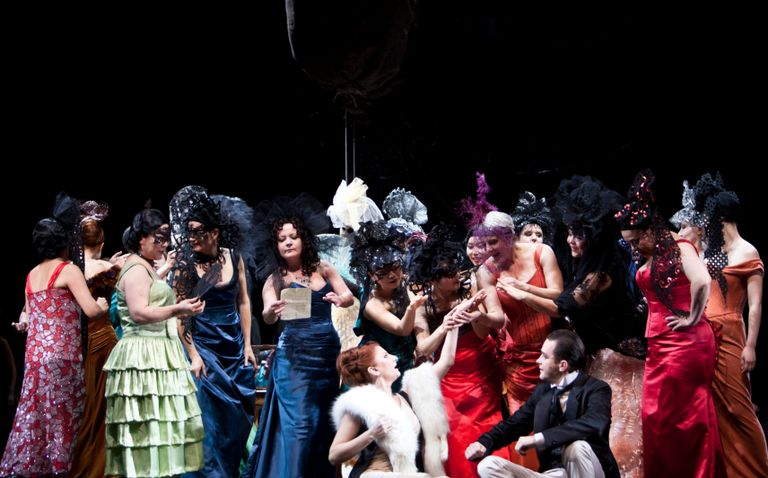

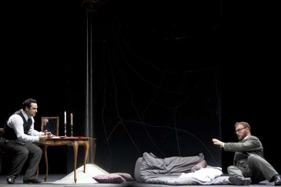

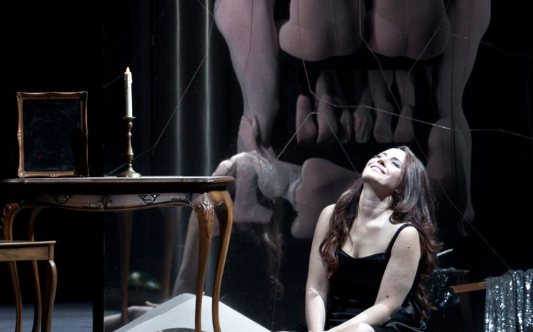

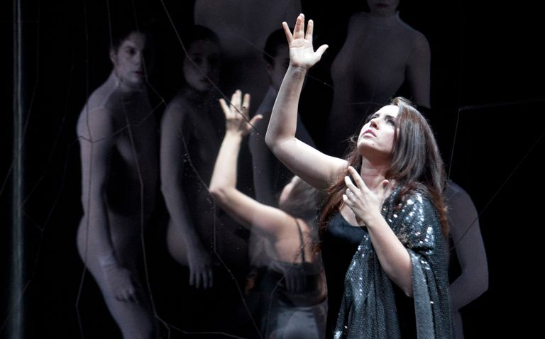

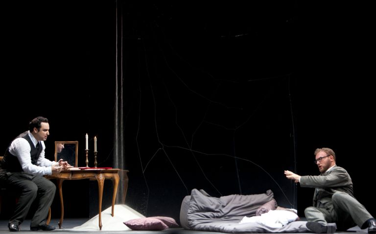

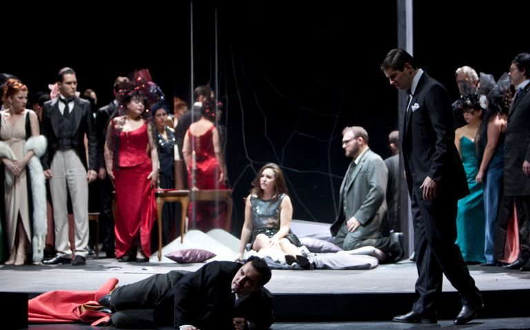

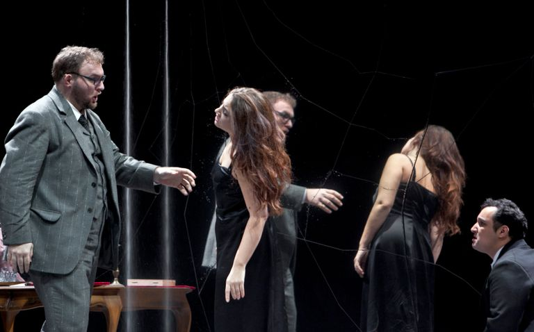

## Handlung

ERSTES BILD  
Violetta Valéry ist krank. Musikalisch wird ihre Geschichte von ihrem Tod her erzählt. Mit ihm beginnt und endet das Stück, der Traum einer unerfüllbaren Liebe. Das Fest, zu dem sie eingeladen hat, soll Arznei gegen die Schwindsucht sein: Im Tumult der Menge, im Taumel, beim gemeinsamen Trinken will sie sich dem Vergnügen überlassen. Gastone, Vicomte de Létorières, stellt ihr einen neuen Gast vor, Alfredo Germont, der sie seit einem Jahr verehrt und ihr seine Liebe und ein ruhiges Leben anbietet. Violetta muss sich entscheiden, für den Baron Douphol, der sie seit einem Jahr bezahlt, oder für Alfredo, der sie so liebt, wie sie es bisher noch nicht erlebt hat. Am frühen Morgen nach dem Weggang ihrer Gäste, sucht Violetta sich klar zu werden, was sie will: eine ernsthafte Liebe oder ein Leben, das ganz im Vergnügen aufgeht. Sie entscheidet sich für Alfredo.  
ZWEITES BILD  
Violetta und Alfredo leben seit drei Monaten auf dem Land. Sie sind glücklich, aber das Geld geht zu Ende. Violetta ist mit Hilfe ihrer Dienerin Annina beschäftigt, ihren Besitz zu veräußern, da sie ja nichts mehr verdient. Alfredo preist sein Glück. In seiner Unbekümmertheit denkt er nicht daran, wer es finanziert. Als ihm Annina sagt, dass Violetta gerade dabei ist, alles zu verkaufen, fährt er nach Paris, um eine andere Lösung zu finden.  
Inzwischen erscheint sein Vater Giorgio Germont bei Violetta. Er wirft ihr vor, das Geld und das Ansehen Alfredos und seiner Familie zu verschleudern. Violetta tritt ihm zunächst entschieden entgegen. Obwohl Germont seinen Irrtum erkennt, argumentiert er mit allen Mitteln und Tricks gegen die Verbindung Violettas mit Alfredo. Er bittet sie Alfredo zu verlassen, um die vorgesehene profitable Verheiratung seiner Tochter nicht zu verhindern. Violetta muss erkennen, dass die »gute Gesellschaft« nicht vergibt, dass ihr neues Leben nicht akzeptiert wird. Da entscheidet sie sich zum radikalen Bruch. Sie wird vortäuschen, in ihr altes Leben zurückzukehren. Die Einladung zu einem Fest bei Flora Bervoix, ihrer Freundin und Konkurrentin, die sie gerade erhalten hat, bietet die Gelegenheit, dort mit dem Baron aufzutreten. Sie schreibt einen Abschiedsbrief an Alfredo, den er nach ihrer Abreise erhält.  
DRITTES BILD  
Das Fest bei Flora. Violetta wird kommen. Es wird darüber gesprochen, dass sie und Alfredo nicht mehr zusammen sind. Das Fest beginnt mit dem Auftritt der Zigeunerinnen, die Flora Bervoix und ihrem Freund, dem Marquis d’Obigny, aus der Hand lesen und diesen wegen seiner fortwährenden Untreue bloßstellen. Auf sie folgt, von Gastone angeführt, eine Gruppe von Stierkämpfern. Sie erzählen die Geschichte des tapferen Piquillo, der fünf Stiere töten muss, um seine Geliebte zu gewinnen. Aber die Festgesellschaft fragt nicht viel nach Tapferkeit, ihr ist es genug, vergnügt zu sein und wagemutig um Geld zu spielen. Violetta erscheint mit dem Baron. Alfredo, der allein gekommen ist, gewinnt im Spiel, auch gegen den Baron. Während alle zum Essen gehen, warnt Violetta Alfredo vor dem Baron. Alfredo will sie zwingen mit ihm wegzugehen. Sie verweigert dies, mit der Begründung nur noch den Baron zu lieben. Daraufhin beleidigt Alfredo Violetta öffentlich, er bezahlt sie mit dem im Spiel gewonnenen Geld. Sein Vater, der in diesem Moment dazu kommt, verurteilt dieses Verhalten ebenso wie der Baron, der ihn zum Duell fordert.  
VIERTES BILD  
Es ist Karneval in Paris. Violetta ist allein mit Annina, der Doktor kommt dazu. Er tröstet die Kranke, sagt aber Annina, dass der Tod bevorstehe. Ein Brief Germonts informiert Violetta darüber, dass das Duell stattgefunden hat. Der Baron wurde verwundet, Alfredo ist auf der Flucht. Sein Vater hat ihm die Wahrheit über Violettas unveränderte Liebe mitgeteilt. Violettas Zustand schwankt zwischen Hoffnung und Todesgewissheit. Noch einmal bricht die lärmende Öffentlichkeit herein, ein maskierter Bacchanalchor. Annina kündigt Alfredo an. Das Liebespaar überbietet sich in gegenseitigen Liebeserklärungen. Violetta will ausgehen, ist aber zu schwach dazu. Die Unmöglichkeit der Liebe wird betrauert. Auch Giorgio Germont, der dazu kommt, stimmt in die allgemeine Trauerstimmung ein. Violetta belebt noch einmal »eine ungewohnte Kraft«. Sie stirbt mit den Worten: »O Freu- - -de«/ »Oh gio- - -ja«.

## Pressestimmen

> »Dieter Dorn inszeniert die Story um die Edelprostituierte Violetta ohne Pause als Fiebertraum der Titelheldin. Der Fokus auf Violetta überzeugt durch kluge Psychologisierungen.«

> **Berliner Morgenpost**

> »Barenboim empfindet ganz offenbar unglaublich viel Sympathie für die Liebenden. Das spürt man bei den ersten mirakulösen, schwebenden Klängen der Streicher ganz zu Beginn der Ouvertüre. Barenboim kostet die wehe Schönheit dieses Todesmotivs aus, als vergösse er hier schon Tränen über das Sterben der armen, lieben Frau. Immer, wenn an diesem Abend von Liebe die Rede sein wird, immer dann zaubert Barenboim eine ungeheure Intensität des Klangs und tritt aus dem ebenmäßigen Zeitmaß heraus, gibt der Liebe so viel Raum und Zeit wie sie braucht.«

> **Süddeutsche Zeitung**

> »Barenboim hat alles im Griff. Die starken ebenso wie die leisen, lyrischen Passagen, das Kontrastprogramm wechselnder Affekte, die geschmeidige Dynamik, das exakte Timing, das sehrende Brio seiner superweichen Staatskapellenholzbläser, die dunklen Farben seiner süßen Staatskapellenstreicher. Und gekrönt wird dieser Verdi-Wunsch-Traum von den frischen, flexiblen Stimmen der jungen Sänger, die Barenboim sich dazu einlud und denen er einen roten Teppich nach dem anderen ausrollt.«

> **FAZ**

> »Dieter Dorn hat eine phantastische Inszenierung zuwege gebracht. Mit ersten Sängerinnen und Sängern, drei Chorsolisten und einer bestens aufgelegten Staatskapelle, geleitet von Daniel Barenboim.«

> **neues deutschland**

> »Überhaupt stellt Dorns Regie den Sängern keine Stolperfallen, stört nicht den musikalischen Fluss. Und das Peepshow-Bühnenbild, entworfen von Joanna Piestrzyńska, befördert ihn sogar, denn im Handumdrehen, blitzschnell, wie es Verdis ökonomisch knappe Szenenwechsel verlanden, kann der komplette Staatsopernchor auf- und wieder abtreten. Eine feine Gesellschaft das: schräg und bunt, karnevalesk kostümiert von Moidele Bickel und ganz famos einstudiert von Martin Wright.«

> **FAZ**

> »Machen wir es kurz und bündig, und spitzen wir es polemisch zu: Die Nähe zu den letzten Dingen ist eine ziemlich gute Voraussetzung, um eine besonders gute Traviata zu produzieren. Dies ist Dieter Dorn gelungen – mit erwähnter künstlerisch unvergleichlicher und energiegeladener Geronto-Truppe, hinreißenden jungen Sängern und einer coolen Bühnenbildnerin, die das Geschehen auf ein Stilleben des 17. Jahrhunderts konzentiert.«

> **rbb - Kulturradio**

## Programmbuch

[Download](https://www.staatsoper-berlin.de/downloads-b/de/produktion/8/programmbuch/e3f0188338da360b2a0ca261ecc29da3/La%20traviata_Programmheft_Auflage2019.pdf)